# Relation between GDP and S&P/TSX index

## find appropriate lags to use in the transfer noise model

In this section, I am trying to identify what lags are used for identifying the relationship between response and explanatory variable. The two variables are difference in GDP, and difference in index. First, I will conduct Prewhiten to the variables, then find the cross-correlation between GDP and stock price. The cross-correlation statistic follows a chi-square distribution, we could use ccf() function to determine the critical value for simplicity. Also, from the cross-correlation plot, it seems like GDP leads stock prices. So let GDP be the explanatory variable and stock prices be the response variable. It turns out that there is no significant relation between response variable and lags of explanatory variable. That is, only $X_t$ should be used to predicting $Y_t$

```
## Series: gdp.obs
## ARIMA(1,0,2)(1,0,0)[4] with non-zero mean
##
## Coefficients:
##          ar1      ma1     ma2     sar1      mean
##       0.8791  -0.7553  0.2041  -0.2953  5847.231
## s.e.  0.0786   0.1066  0.1063   0.0861  1029.197
##
## sigma^2 estimated as 20100799:  log likelihood=-1393.23
## AIC=2798.46   AICc=2799.08   BIC=2816.2
##
## Training set error measures:
##                    ME     RMSE     MAE        MPE     MAPE      MASE
## Training set 91.32209 4403.751 3393.52 -0.3477519 128.0677 0.6636525
##                     ACF1
## Training set 0.003816013
```

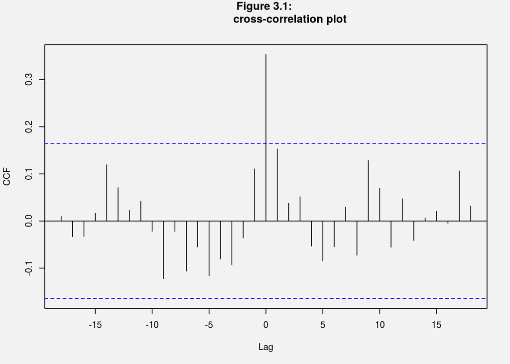

## fit linear regression

Suppose a least square linear model is adequate to describe the relationship between the response and explanatory variables, then we are going to fit a linear regression model between response and explanatory variable. Recall the assumption of linear regression:
$$E(e_i) = 0\\
Var(e_i) = \sigma^2\\
Cov(e_i,e_j)= 0 \text{ } \forall i \ne j$$
then if the model is adequate then there should be no serial correlation between residuals $\hat{e}_i$. It turns out that there is no serial correlation between residuals, so this linear model is adequate to describe the relationship between the variables. There is no need to use the TFN model

```
##
## Call:
## lm(formula = tsx.ts ~ gdp.ts)
##
## Residuals:
##     Min      1Q  Median      3Q     Max
## -3388.3  -235.9    39.1   322.0  1167.4
##
## Coefficients:
##               Estimate Std. Error t value Pr(>|t|)
## (Intercept) -1.764e+02  7.567e+01  -2.331    0.021 *
## gdp.ts       4.280e-02  9.446e-03   4.531 1.15e-05 ***
## ---
## Signif. codes:  0 '***' 0.001 '**' 0.01 '*' 0.05 '.' 0.1 ' ' 1
##
## Residual standard error: 591.4 on 158 degrees of freedom
## Multiple R-squared:  0.115,  Adjusted R-squared:  0.1094
## F-statistic: 20.53 on 1 and 158 DF,  p-value: 1.154e-05
```

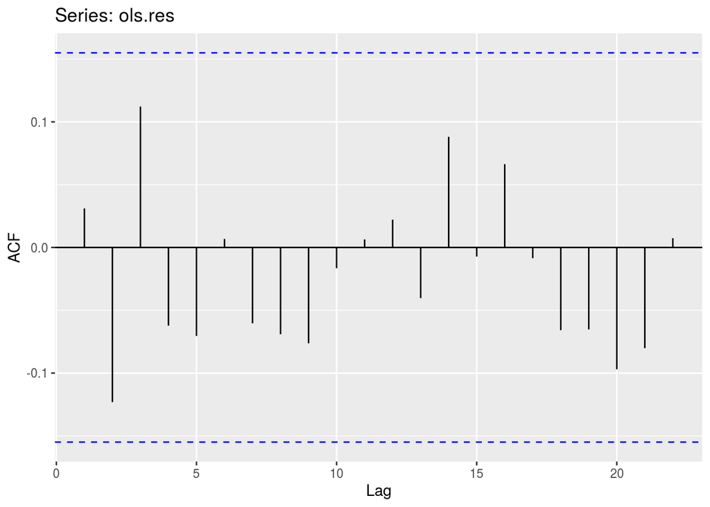

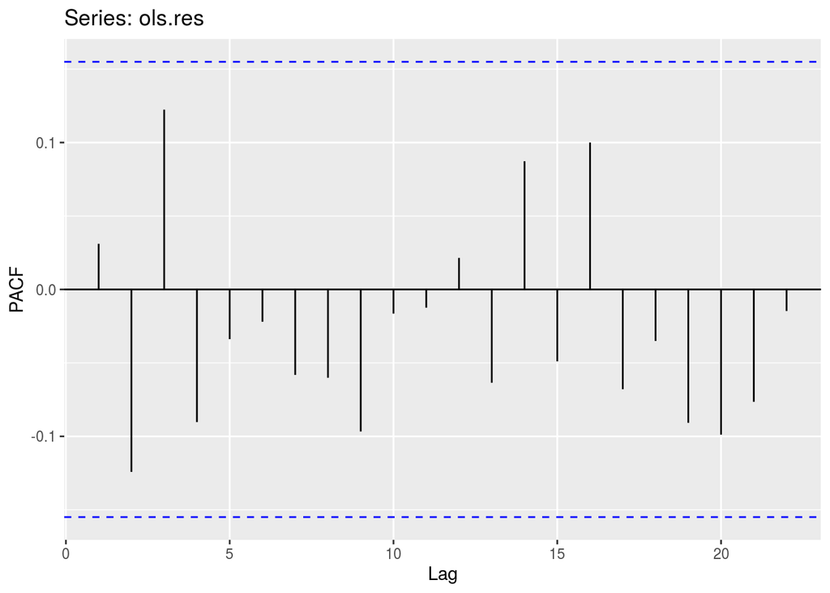

## Testing and Predicting

In this section we will predict the response varible using the linear model and arima model. We decide to use Mean Square Error(MSE) as the performance metric. We also try to ensemble the two model by finding the weight that minimize MSE. It turns out that the MSE are 649.36, 695.40 and 649.25 for linear model, arima, and ensemble model respectively. So the linear model alone is pretty good. Note that although the arima model is not very bad in terms of MSE, but it seems fail to modeling the movement of response variable, and the ensemble model only has negligible MSE improvement compare to the linear model, so the arima model is completely garbage. This observation strengthens our beliefs that the explanatory is helpful in predicting the response, because the arima model only use the response variable alone. The prediction are shown in the figure below.

[interactive chart not shown]

```
## $selection
## AIC(n)  HQ(n)  SC(n) FPE(n)
##      4      1      1      4
##
## $criteria
##                   1            2            3            4            5
## AIC(n) 2.960468e+01 2.957757e+01 2.960673e+01 2.953911e+01 2.954548e+01
## HQ(n)  2.967430e+01 2.968201e+01 2.974598e+01 2.971318e+01 2.975436e+01
## SC(n)  2.977601e+01 2.983457e+01 2.994939e+01 2.996744e+01 3.005948e+01
## FPE(n) 7.197188e+12 7.005277e+12 7.213656e+12 6.743803e+12 6.789546e+12
##                   6            7            8            9           10
## AIC(n) 2.959217e+01 2.962298e+01 2.967618e+01 2.971950e+01 2.974476e+01
## HQ(n)  2.983586e+01 2.990148e+01 2.998949e+01 3.006763e+01 3.012769e+01
## SC(n)  3.019184e+01 3.030831e+01 3.044718e+01 3.057617e+01 3.068709e+01
## FPE(n) 7.117920e+12 7.345952e+12 7.754572e+12 8.107399e+12 8.326713e+12
```

```
## [1] TRUE
```

|  | eigen max | 10pct | 5pct | 1pct |
| --- | --- | --- | --- | --- |
| r <= 1 \| | 13.51454 | 7.52 | 9.24 | 12.97 |
| r = 0 \| | 76.80367 | 13.75 | 15.67 | 20.20 |

[interactive chart not shown]

## Final ensemble: In this section, we will ensemble prediction generated by the linear model and the VAR model using the MSE minimization method. Recall that the two time series I used for linear model are differencing in gdp as the explanatory and differencing in index as the response, the prediction from linear model is also the differencing in index, so a transformation is needed, and this could be done in just few lines of code. It turns out that the ensembles model is the best in terms of MSE. The prediction is shown below.

[interactive chart not shown]

# Discussion

## Summary:

First of all, I transform variables and find leading(explanatory) variable and response variable then find lags. Next, train linear regression model, and see if a transfer noise model is needed What’s more, train Arima model and ensemble linear model and Arima model by minimize MSE and train VAR model. Lastly, ensemble linear model and VAR model by minimize MSE.

## Conclusion:

By examining the graph of the prediction and the test data, I think my prediction is good, it kind of capture the movement of the index and the overall trend. I get the conclusion that these two indexes are related, GDP leads the S&P Composite Index. As I mentioned in the following section, some possible improvements can be made in the future. Also, I found time series analysis is actually very interesting, time on its own is fascinating. Although I am just in the starting level. In this subject, I hope to learn more about it in the future.

## Weaknesses

Based on my knowledge from economics, it is naive to use only one variable-GDP(an macroeconomic factor) to predict stock index which is an microeconomic factor after all. The data have small sample bias since I only chose about 36 years, and excluded the recent data due to large fluctuation caused by Covid-19.

## Next Steps

I would say adding more explanatory variables would be helpful. Such as unemployment rate, firm’s retention rate etc. In addition, conduct intervention analysis to deal with problems like externality, government policy and financial crisis might be helpful.

# References

1. https://www150.statcan.gc.ca/n1/en/type/data?text=GDP+2020
2. Yahoo Finance-S&P/TSX
3. https://www.encyclopedia.com/social-sciences/applied-and-social-sciences-magazines/vector-autoregression#:~:text=Vector%20autoregression%20%28VAR%29%20models%20were%20introduced%20by%20the,macroeconomic%20variables.%20VAR%20models%20are%20useful%20for%20forecasting.